# Lab 2: Data Manipulation and Visualization

##### 2.3.1.2 Aesthetic Mapping

Recall our previous code,

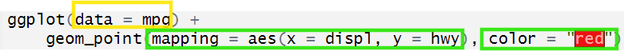

Aesthetics in `geom_xxx()` statement can be specified in two ways:

1. **inside** the `aes()` function, which maps **variables** to aesthetics to represent or enhance visual features.
2. **outside** the `aes()` function, which takes **fixed values**. This step is usually optional.

`geom_xxx(aes(ARGUMENTS = variable, ...), ARGUMENTS = fixed values)`. Some commonly used aesthetics are:

- `x`, `y`: define the variables for the x- and y-axes (must be inside `aes()`).
- `color`: defines the color of lines and strokes.
- `fill`: defines the color inside areas of geoms.
- `shape`: defines the symbols of points.
- `size`: defines the size of points.
- `alpha`: defines the opacity of geoms.

The examples below show the difference between mapping variables and mapping fixed values to aesthetics.

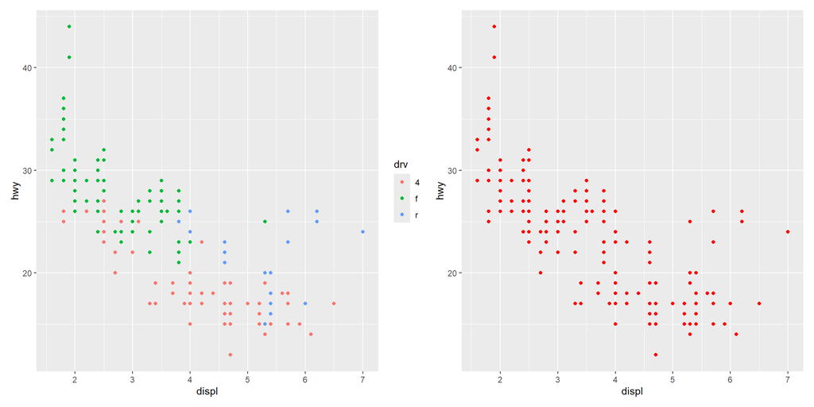

```r
p1 <- ggplot(data = mpg) +
        geom_point(mapping = aes(x = displ, y = hwy, color = drv)) # map variable to color

p2 <- ggplot(data = mpg) +
        geom_point(mapping = aes(x = displ, y = hwy), color = "red") # color now is mapped by a fixed value

p1 + p2 # enabled by "patchwork"
```

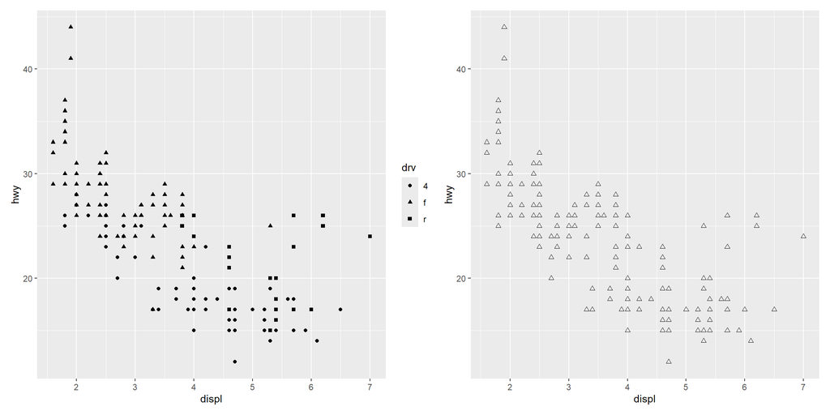

```r
p3 <- ggplot(data = mpg) +
        geom_point(mapping = aes(x = displ, y = hwy, shape = drv))  # map variable to shape

p4 <- ggplot(data = mpg) +
        geom_point(mapping = aes(x = displ, y = hwy), shape = 2)  # shape now is mapped by a fixed value

p3 + p4
```

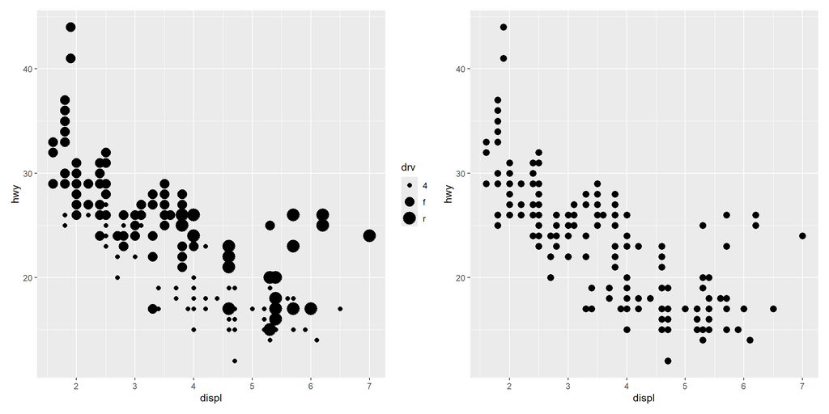

```r
p5 <- ggplot(data = mpg) +
        geom_point(mapping = aes(x = displ, y = hwy, size = drv))  # map variable to size

p6 <- ggplot(data = mpg) +
        geom_point(mapping = aes(x = displ, y = hwy), size = 3)  # size now is mapped by a fixed value

p5 + p6
```

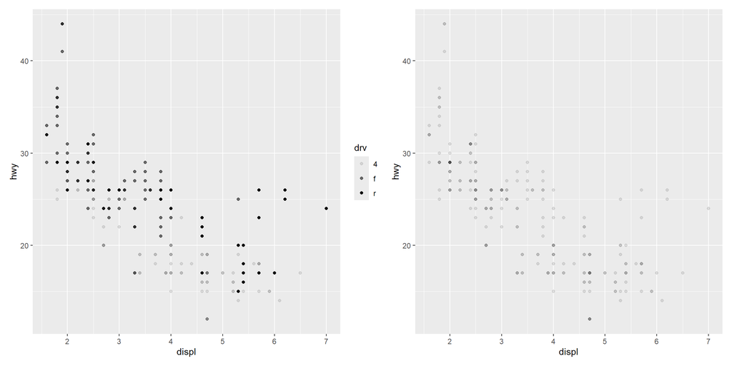

```r
p7 <- ggplot(data = mpg) +
        geom_point(mapping = aes(x = displ, y = hwy, alpha = drv))  # map variable to alpha

p8 <- ggplot(data = mpg) +
        geom_point(mapping = aes(x = displ, y = hwy), alpha = 0.1)  # alpha now is mapped by a fixed value

p7 + p8
```

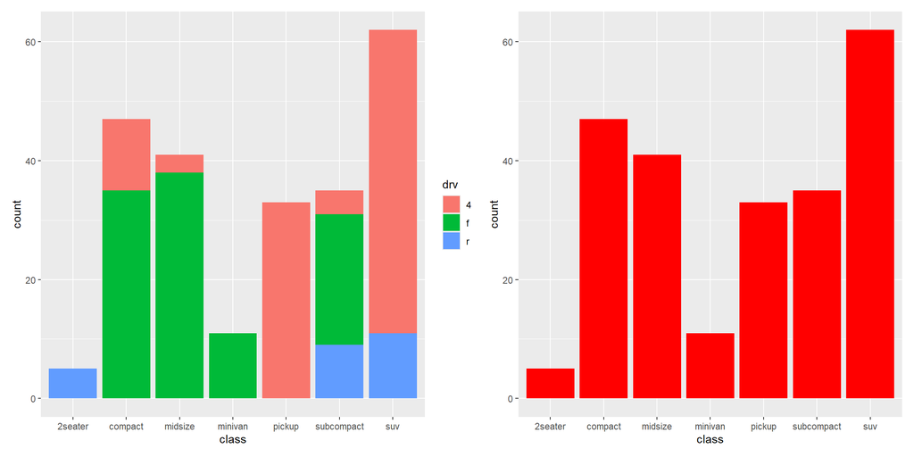

```r
p9 <- ggplot(data = mpg) +
        geom_bar(mapping = aes(x = class, fill = drv))  # map variable class to fill

p10 <- ggplot(data = mpg) +
       geom_bar(mapping = aes(x = class), fill = "red")  # fill now is mapped by a fixed value

p9 + p10
```

##### 2.3.1.3 Commonly Used Fixed Values

As shown above, **fixed values** mapped to aesthetics are usually numbers or strings. Below are some commonly used fixed values for `geom` functions:

- `color` and `fill`: see [R color cheatsheet](https://www.nceas.ucsb.edu/sites/default/files/2020-04/colorPaletteCheatsheet.pdf).
- `linetype` and `shape`: see [Cookbook for R](http://www.cookbook-r.com/Graphs/Shapes_and_line_types/)
- `size`: takes numeric values; larger values correspond to larger sizes.
- `alpha`: takes values between 0 and 1; larger values correspond to less transparency.
- Some extra examples are shown below

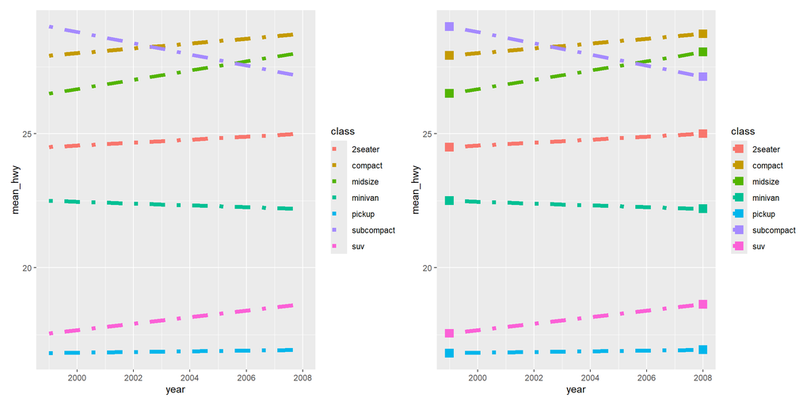

```r
mpg_class_year_hwy <- mpg %>% group_by(class, year) %>% summarize(mean_hwy = mean(hwy))

p11 <- ggplot(data = mpg_class_year_hwy, aes(year, mean_hwy, color = class)) +
        geom_line(size = 2, linetype = "dotdash")

p12 <- ggplot(data = mpg_class_year_hwy, aes(year, mean_hwy, color = class)) +
        geom_line(size = 2, linetype = 4) +
        geom_point(size = 4, shape = 15)

p11 + p12
```

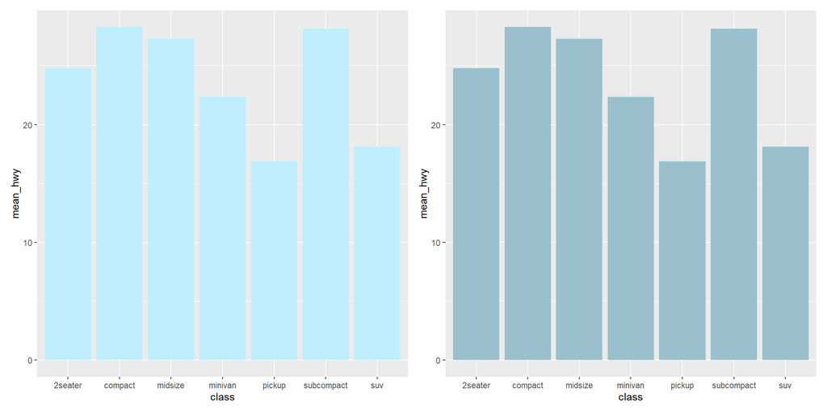

```r
mpg_class_hwy <- mpg %>% group_by(class) %>% summarize(mean_hwy = mean(hwy))

p13 <- ggplot(data = mpg_class_hwy, mapping = aes(x = class, y = mean_hwy)) +
        geom_col(fill = "lightblue1")

p14 <- ggplot(data = mpg_class_hwy, mapping = aes(x = class, y = mean_hwy)) +
        geom_col(fill = "lightblue3")

p13 + p14
```

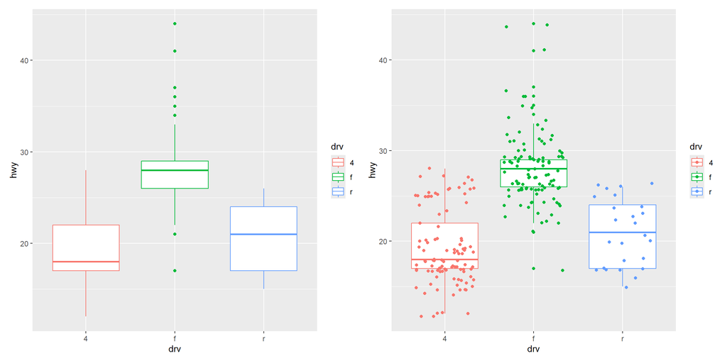

```r
p15 <- ggplot(data = mpg, aes(x = drv, y = hwy, color = drv)) +
        geom_boxplot()

p16 <- ggplot(data = mpg, aes(x = drv, y = hwy, color = drv)) +
        geom_boxplot() +
        geom_jitter(width = 0.333)

p15 + p16
```

#### 2.3.2 Facets

`facet_wrap()`: partitions a plot into a matrix of panels, typically based on the values of **one faceting variable**. Each panel shows a different subset of the data.

`facet_grid()`: partitions a plot into a matrix of panels, based on the combination of **two faceting variables**.

Following the previous practice, let us create a line plot to show the trend of average fuel efficiency for each manufacturer.

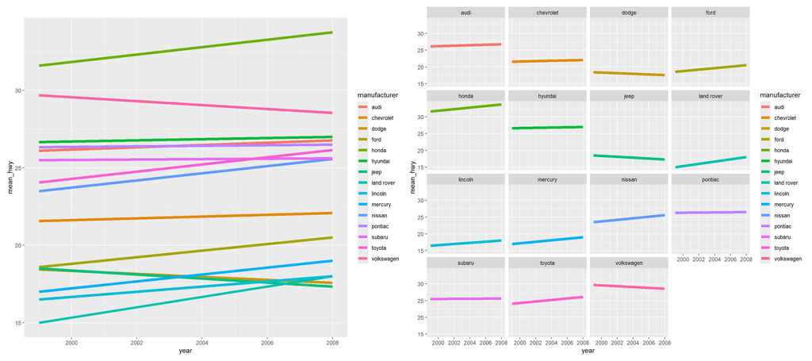

```r
mpg_mfr_year_hwy <- mpg %>% group_by(manufacturer, year) %>% summarize(mean_hwy = mean(hwy))

p17 <- ggplot(data = mpg_mfr_year_hwy, aes(year, mean_hwy, color = manufacturer)) +
        geom_line(size = 2)

p18 <- ggplot(data = mpg_mfr_year_hwy, aes(year, mean_hwy, color = manufacturer)) +
        geom_line(size = 2) +
        facet_wrap(~ manufacturer)

p17 + p18
```

As you can see in “p17”, the graph is not effective in showing the trend in fuel efficiency across time for some of the manufacturers. “p18” partitions the plot into subplots for each individual manufacturer. Since all panels share the same scale for “mean_hwy”, the graph is still not effective. To improve, you can add `scales = "free"` to allow different scales for subplots.

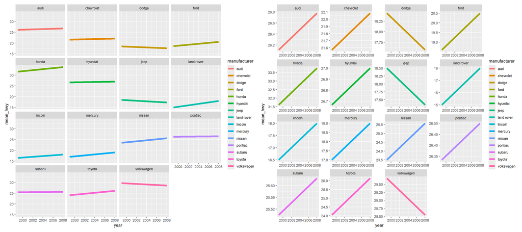

```r
p19 <- ggplot(data = mpg_mfr_year_hwy, aes(year, mean_hwy, color = manufacturer)) +
        geom_line(size = 2) +
        facet_wrap(~ manufacturer, scales = "free")

p18 + p19
```

Now, let’s see how `facet_wrap()` differs from `facet_grid()`, starting with graph(s) showing “hwy” vs. “displ”.

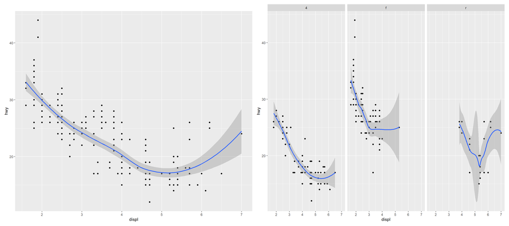

```r
p20 <- ggplot(data = mpg, mapping = aes(x = displ, y = hwy)) +
        geom_point() +
        geom_smooth()

p21 <- ggplot(data = mpg, mapping = aes(x = displ, y = hwy)) +
        geom_point() +
        geom_smooth() +
        facet_wrap(~drv)

p20 + p21
```

As shown below, `facet_wrap()` shows the relationship for each value of **“drv”**, while `facet_grid()` shows the relationship for each combinations of the values of **“drv”** and **fl**.

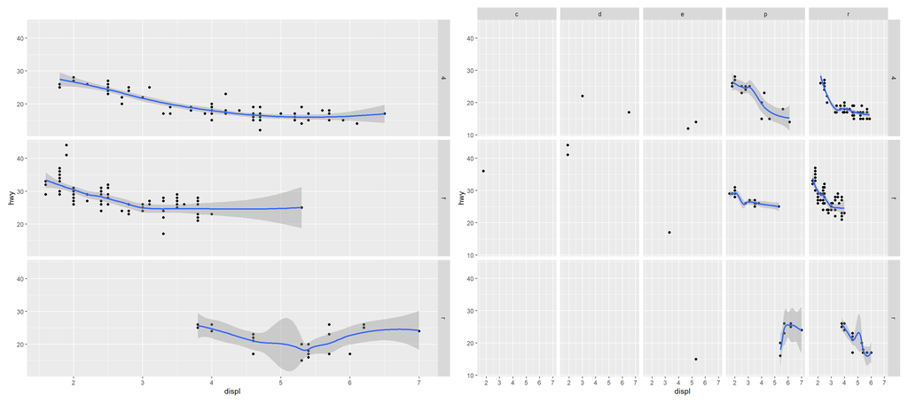

```r
p22 <- ggplot(data = mpg, mapping = aes(x = displ, y = hwy)) +
        geom_point() +
        geom_smooth() +
        facet_wrap(~drv, nrow = 3, strip.position = "right") # adding nrow and strip.position for better visualization

p23 <- ggplot(data = mpg, mapping = aes(x = displ, y = hwy)) +
        geom_point() +
        geom_smooth() +
        facet_grid(drv ~ fl)

p22 + p23
```

#### 2.3.3 Scales

##### 2.3.3.1 Scales of Axes

This section explores some common functions that scale the axes of your graph.

- When mapping **discrete variables**: the default functions are `scale_x_discrete()` for the x-axis, and `scale_y_discrete()` for the y-axis.
- When mapping **continuous variables**: the default functions are `scale_x_continuous()` for the x-axis, and `scale_y_continuous()` for the y-axis.
  - Built-in functions like `scale_x_log10()`, `scale_x_sqrt()`, and `scale_x_reverse()` provide easy access to common transformations: base-10 logarithm, square root, and reversed order.

For this section, let’s use a new dataset from the package *gapminder*. See how arguments `limits` controls the min/max of the axes, and `breaks` displays ticks only at specified values.

```r
glimpse(gapminder)
```

```
Rows: 1,704
Columns: 6
$ country   <fct> "Afghanistan", "Afghanistan", "Afghanistan", "Afghanistan", …
$ continent <fct> Asia, Asia, Asia, Asia, Asia, Asia, Asia, Asia, Asia, Asia, …
$ year      <int> 1952, 1957, 1962, 1967, 1972, 1977, 1982, 1987, 1992, 1997, …
$ lifeExp   <dbl> 28.801, 30.332, 31.997, 34.020, 36.088, 38.438, 39.854, 40.8…
$ pop       <int> 8425333, 9240934, 10267083, 11537966, 13079460, 14880372, 12…
$ gdpPercap <dbl> 779.4453, 820.8530, 853.1007, 836.1971, 739.9811, 786.1134, …
```

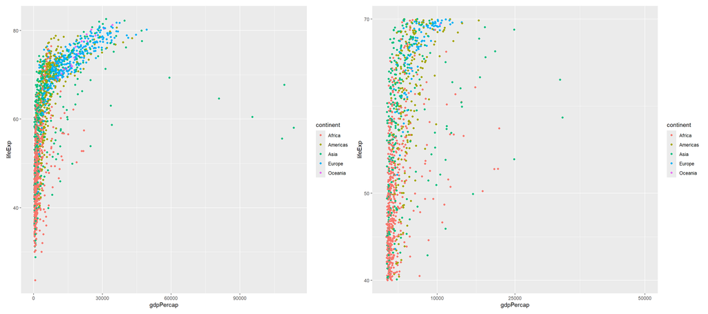

```r
base_plot <- ggplot(gapminder, aes(x = gdpPercap, y = lifeExp, color = continent)) +
              geom_point()

scale_x_y <- base_plot +
              scale_x_continuous(limits = c(0, 50000), breaks = c(10000, 25000, 50000)) +
              scale_y_continuous(limits = c(40, 70), breaks = c(40, 50, 70))

base_plot + scale_x_y
```

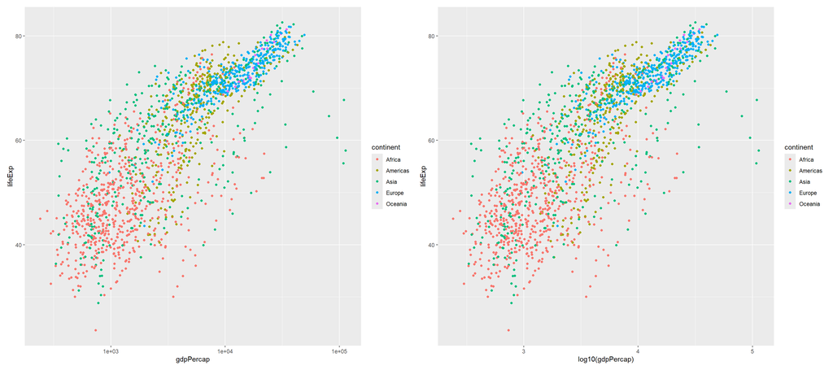

```r
built_in_log10 <- base_plot + scale_x_log10()

manual_log10 <- ggplot(gapminder, aes(x = log10(gdpPercap), y = lifeExp, color = continent)) +
                  geom_point()

built_in_log10 + manual_log10
```

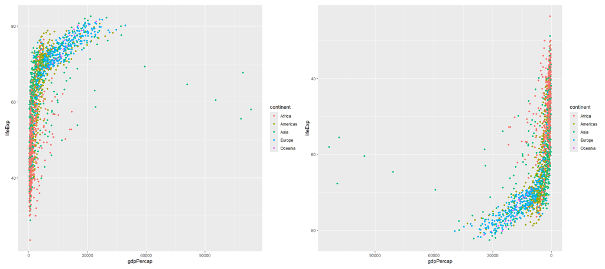

```r
base_plot_reverse <- base_plot + scale_x_reverse() + scale_y_reverse()

base_plot + base_plot_reverse
```

##### 2.3.3.2 Scales of Colors

Recall you can set the color of your graphs using the aesthetics `color` and/or `fill`.

```r
# building a simple dataframe
mydata <- data.frame(x = c("a", "b", "c", "d"), y = c(1, 2, 3, 4))
mydata
```

| x | y |
| --- | --- |
| a | 1 |
| b | 2 |
| c | 3 |
| d | 4 |

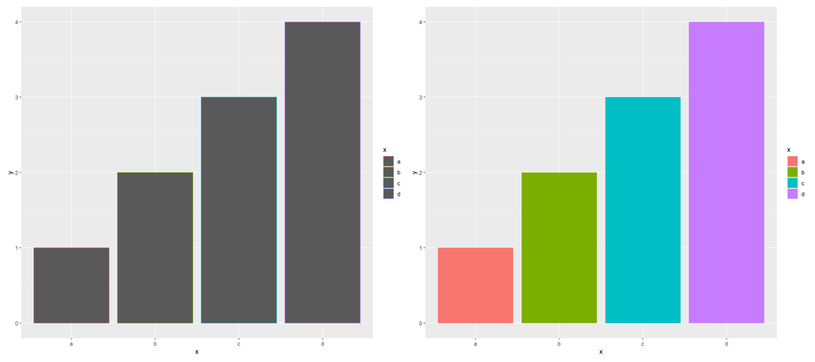

```r
bar_color <- ggplot(mydata, aes(x = x, y = y, color = x)) + geom_col()
bar_fill  <- ggplot(mydata, aes(x = x, y = y, fill = x))  + geom_col()

bar_color + bar_fill
```

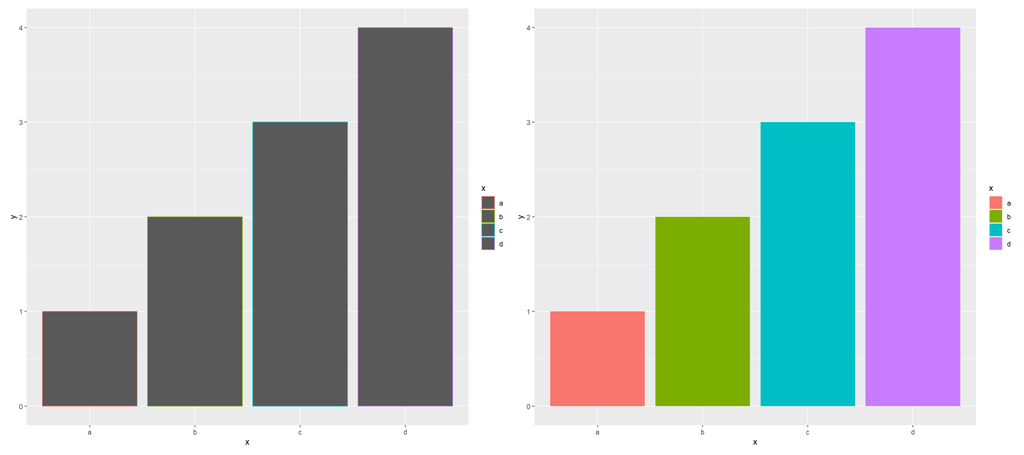

```r
bar_color_scale <- bar_color + scale_color_discrete()  # since x is discrete now
bar_fill_scale  <- bar_fill  + scale_fill_discrete()

bar_color_scale + bar_fill_scale # no changes since we are using defaults
```

To assign different colors to different values of “x”, we can utilize the function `scale_fill_brewer()`, which uses the color palettes from the package *RColorBrewer* without the need of installing and loading the package. To see all the colors, check [this link](https://r-graph-gallery.com/38-rcolorbrewers-palettes.html) or type `RColorBrewer::display.brewer.all()`.

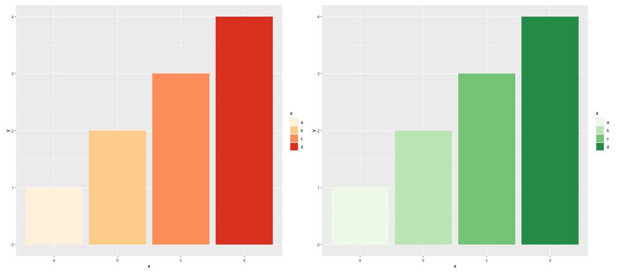

```r
bar_fill_brewer_1 <- bar_fill + scale_fill_brewer(palette = "OrRd")

bar_fill_brewer_2 <- bar_fill + scale_fill_brewer(palette = "BrBg")

bar_fill_brewer_1 + bar_fill_brewer_2
```

#### 2.3.4 Labs and Themes

To modify elements of a plot other than the data, such as axes, legend, or title, use `labs()` and `theme()`. See how the example below applies changes to the graph “bar_fill” on axis, legend and plot title.

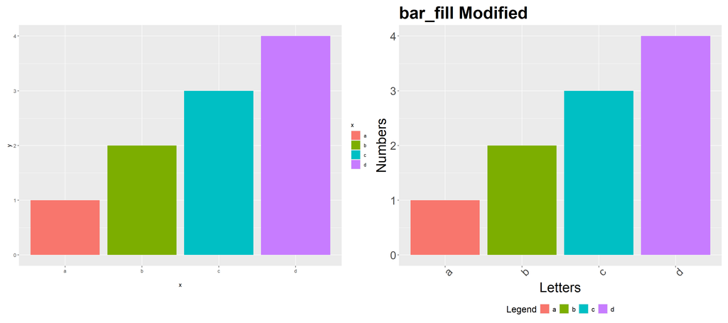

```r
bar_fill_mod <- bar_fill + labs(x = "Letters", y = "Numbers", fill = "Legend", title = "bar_fill Modified") +
                                theme(
                                  axis.title = element_text(size = 24),
                                  axis.text = element_text(size = 20),
                                  axis.text.x = element_text(angle = 45),

                                  legend.title = element_text(size = 16),
                                  legend.text = element_text(size = 12),
                                  legend.position = "bottom",

                                  plot.title = element_text(size = 30, face = "bold")
                                )


bar_fill + bar_fill_mod
```

#### 2.3.5 Built-in Themes

There are a number of built-in themes come with *ggplot2* that you can use without the need to specify every element of your graphs. The default theme of *ggplot2* is `theme_grey()`. Let’s see some examples on our base plot below.

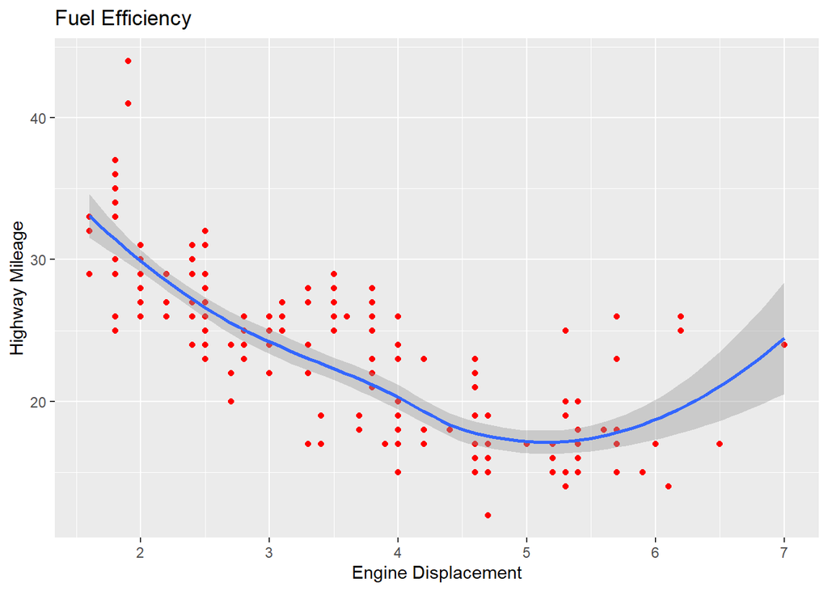

```r
base_theme <- ggplot(data = mpg, aes(x = displ, y = hwy)) +
                geom_point(color = "red") +
                geom_smooth() +
                labs(x = "Engine Displacement", y = "Highway Mileage", title = "Fuel Efficiency")
base_theme
```

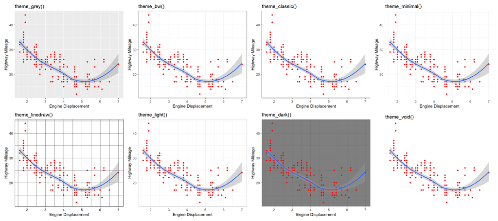

```r
base_theme_default <- base_theme + theme_grey() + labs(title = "theme_grey()")

base_theme1 <- base_theme + theme_bw() + labs(title = "theme_bw()")

base_theme2 <- base_theme + theme_classic() + labs(title = "theme_classic()")

base_theme3 <- base_theme + theme_minimal() + labs(title = "theme_minimal()")

base_theme4 <- base_theme + theme_linedraw() + labs(title = "theme_linedraw()")

base_theme5 <- base_theme + theme_light() + labs(title = "theme_light()")

base_theme6 <- base_theme + theme_dark() + labs(title = "theme_dark()")

base_theme7 <- base_theme + theme_void() + labs(title = "theme_void()")

(base_theme_default + base_theme1 + base_theme2 + base_theme3 +
 base_theme4 + base_theme5 + base_theme6 + base_theme7) +
  plot_layout(ncol = 4, nrow = 2)
```

Extra themes and scales can be acquired by installing package *ggthemes*. To see the complete list, visit [this webiste](https://jrnold.github.io/ggthemes/?utm_source=chatgpt.com).

### 2.4 Annotating and Saving Plots

Sometimes, you may wish to add text in your graphs to highlight certain elements. Take “base_plot” in Section 2.3.3 for example, say you wish to highlight countries with high GDP per capita (above $50,000) but low life expectancy (below 70 years old).

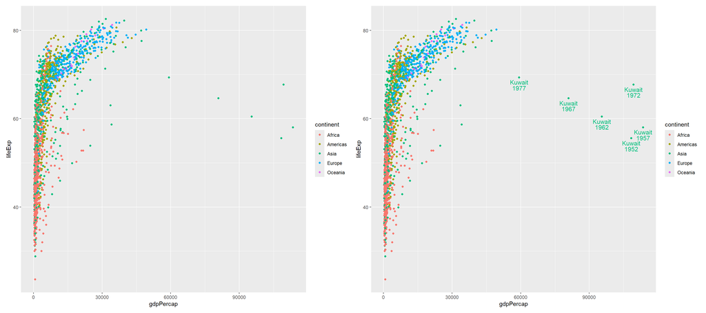

```r
h_country <- gapminder %>% filter(gdpPercap > 50000 & lifeExp < 70) # create the data that's to be highlighted in the graph

base_plot_text <- base_plot +
                    geom_text(data = h_country, aes(label = country), size = 4, vjust = 1.5, show.legend = FALSE) +
                    geom_text(data = h_country, aes(label = year), size = 4, vjust = 2.75, show.legend = FALSE)

base_plot + base_plot_text
```

To save a created plot, you can use the function `ggsave()` as below.

```r
ggsave("gdp_lifeExp.png", plot = base_plot_text, width = 10, height = 7)  # save to your current working directory

# you can save ggplot as one of "eps", "ps", "tex", "pdf", "jpeg", "tiff", "png", "bmp", "svg" or "wmf"
# you can also use different units = c("in", "cm", "mm", "px"),
# ggsave("myplot.pdf", width = 20, height = 20, units = "cm")
```

### 2.5 Useful resources

#### 2.5.1 ggplot2 Cheat Sheet

[Click here for more information](https://rstudio.github.io/cheatsheets/data-visualization.pdf)

[figure not shown]

[figure not shown]

#### 2.5.2 R for Data Science

See Chapter 3 and 28 of [R for Data Science, by Wickham, H., & Grolemund, G.](https://cran.r-project.org/doc/manuals/r-release/R-intro.pdf)

#### 2.5.3 ggplot2: Elegant Graphics for Data Analysis

See the third edition of [ggplot2: Elegant Graphics for Data Analysis, by Hadley Wickham, Danielle Navarro, and Thomas Lin Pedersen](https://ggplot2-book.org/).

### 2.6 Exercise

#### Part A

Import data “mpg” and work through the exercises below.

1. Create a scatterplot that shows all of the following:
   1. use “cty” on the x-axis and “hwy” on the y-axis
   2. assign different colors for “class” and different shapes for “year”.  
      (tip: since continuous variables cannot be mapped to `shape`, you will need to convert “year” to a factor using `factor()`)
   3. fit **only one trend line** for all points
2. Create a scatterplot that shows all of the following:
   1. use “displ” on the x-axis and “hwy” on the y-axis
   2. partition the graph into a grid by the combination of “drv” and “fl”, but only include “fl” that equals “p” or “r”
   3. fit a trend line in each graph within the grid

   (Tip: you can build from the example “p23” in Lab 2.)
3. Create a bar chart that shows the average “hwy” of all cars produced in 2008 by each of the following manufacturers:  
   **Audi**, **Hyundai**, **Nissan** and **Volkswagen**. Assign a different color to each manufacturer.

#### Part B

Import the data “gapminder” and try to reproduce the graph below.

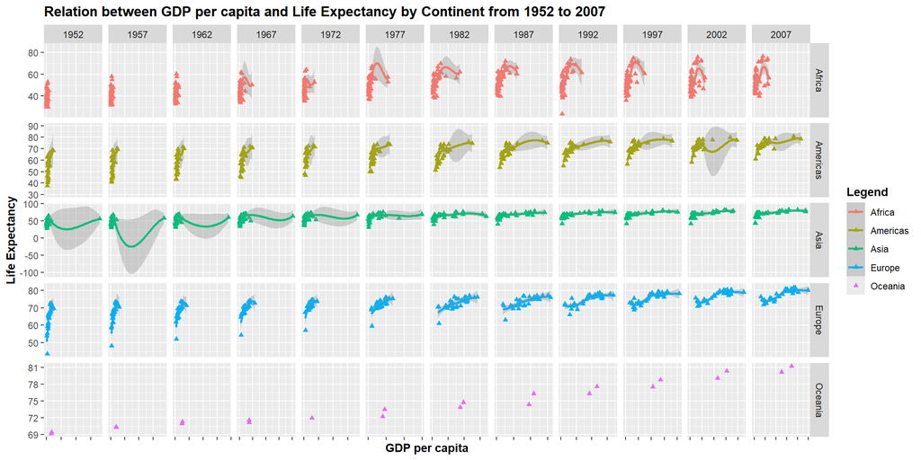